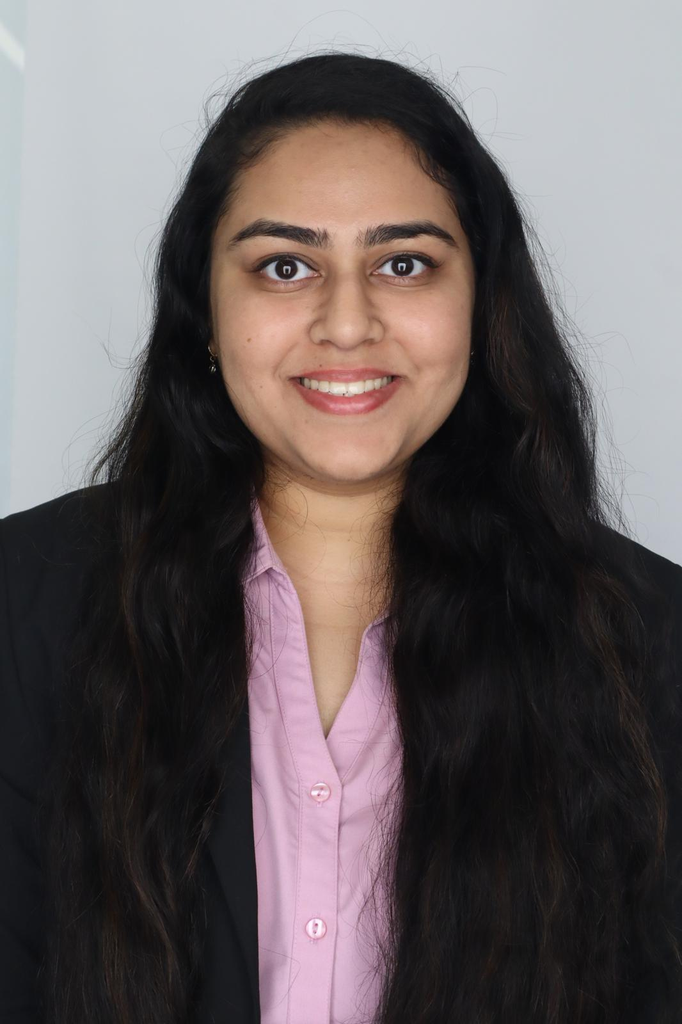

# Dr. Madhura Karve, PharmD

## About Me

### Summary

Clinical researcher with 2+ years of sponsor-side trial operations and scientific affairs experience, completing an ScM in Epidemiology (Clinical Trials & Evidence Synthesis) at Johns Hopkins. Managed 3 concurrent RCTs as primary sponsor contact across 25+ monitoring visits under ICH-GCP E6(R2), authored core trial documents end to end, and published 5 peer-reviewed papers. Pairs hands-on execution (REDCap, EDC, IP accountability, site and vendor oversight) with epidemiologic and biostatistical methods to generate decision-ready evidence.

### Background

- I’m a clinical researcher and pharmacist by training.
- I earned my Doctor of Pharmacy from Poona College of Pharmacy, Bharati Vidyapeeth (Deemed) University in Pune, India, where I graduated as the University Gold Medallist.
- Before coming to Hopkins I spent two years at Indus Biotech Ltd. as an Executive in Scientific Affairs, serving as the primary sponsor contact for three concurrent randomized controlled trials and authoring protocols, Investigator Brochures, CRFs, and Clinical Study Reports end to end.

## Education

**Johns Hopkins University** | Baltimore, MD

Master of Science in Epidemiology | Aug 2025 - May 2027

- *Clinical Trials and Evidence Synthesis* track; GPA: 3.68 / 4.0
- Relevant coursework: Epidemiologic Methods I–III; Statistical Methods in Public Health I–IV; Introduction to Clinical Trials; Systematic Review & Meta-Analysis; Pharmacoepidemiology; Causal Inference in Medicine I; Risk Sciences and Public Policy.

**Bharati Vidyapeeth Poona College of Pharmacy** | Pune, India

Doctor of Pharmacy | Aug 2017 - Jun 2023

- 86.6%, University Gold Medallist

## Research Interests

- My goal is to combine epidemiologic methods, biostatistical skills, and hands-on trial experience to generate trusted evidence on the safety, efficacy, and real-world viability of new medications.
- Concretely, that means clinical trial design and conduct, systematic review and meta-analysis, pharmacoepidemiology and drug safety.
- I’m drawn to work that blends scientific rigor, operational execution, and patient impact.

## Skills

### Statistics & Data Analysis

- Statistical software: SPSS, STATA, R; SAS (familiar); GraphPad Prism.
- Graduate coursework: Statistical Methods in Public Health I–IV, Epidemiologic Methods I–III, Causal Inference in Medicine I, Systematic Review & Meta-Analysis, Pharmacoepidemiology.
- Primary researcher on a 212-patient prospective study of health-related quality of life in breast cancer patients (recruitment, consent, and SPSS analysis).
- Designed and piloted a survey instrument for 202 pregnant women and analyzed adherence determinants in SPSS.

### Programming

- R: comfortable with base R and basic data cleaning; new to the tidyverse and functions.
- Git and GitHub: new to version control; this site is my first GitHub repository.
- Well-versed with STATA for statistical data analysis.(140.621 to 140.624 - Statistical Methods I to IV)
- Attended SPSS course by CliMed to run different analyses on medium sized datasets.

### Data Management & Clinical Research

- REDCap and Medidata iMedidata (EDC): CRF design, data entry, query resolution, data cleaning and digitization.
- Managed three concurrent RCTs as primary sponsor contact across 25+ site initiation, monitoring, and close-out visits under ICH-GCP E6(R2).
- Co-author on five peer-reviewed publications (see [ORCID](https://orcid.org/0009-0008-9223-845X)).

### Technical Skills & Certifications

- **Clinical Operations:** ICH-GCP E6(R2), protocol development, site initiation/monitoring/close-out visits, source data verification, investigational product (IP) accountability and inventory, CRO and vendor selection and oversight, study start-up, IRB/Ethics Committee and CTRI regulatory submissions, informed consent, ADR/SAE reporting (CIOMS).
- **Data & Systems:** REDCap, iMedidata (EDC).
- **Statistics & Analysis:** SPSS, STATA, SAS (familiar); GraphPad Prism.
- **Scientific Writing:** Protocols, Investigator Brochures (IBs), CRFs, Clinical Study Reports (CSRs), logs and forms, manuscripts, systematic literature review; EndNote.
- **Certifications:** Good Clinical Practice (ICH-GCP), 2023; Pharmacoepidemiology and Drug Safety; Lean Six Sigma Green Belt, 2023; Goethe-Zertifikat German A2 (93/100), 2022.

## Research & Clinical Trial Experience

**Graduate Research Assistant | Graduate Research Intern** | Baltimore, MD

*Center for Clinical Trials and Evidence Synthesis (CCTES), Johns Hopkins BSPH* | June 2026 – Present

- Perform REDCap data entry and resolve data queries across studies, maintaining data quality and audit-ready documentation.
- Prepare operational study documents including participant visit and post-visit checklists used by site staff.
- Manage investigational product (IP) inventory.

**Graduate Research Assistant** | Baltimore, MD

*Department of Epidemiology, Johns Hopkins BSPH* | January 2026 – Present

- **Clinical Trials Curriculum Development (Jan – Apr 2026):** Developed and curated course materials for a graduate clinical trials curriculum, including literature synthesis, evidence-based content review, and slide deck development.
- **COAST/ACCIDDA Survey & Serology Study (Jun 2026):** Entered and managed survey data on COVID-19, influenza, and RSV vaccination status and infection outcomes.
- **Mozambique Vaccine Coverage Study (Jul 2026 – Present):** Digitized and cleaned immunization records from physical vaccine cards (BCG, polio, DPT, Hib, HepB, PCV, RV, measles/rubella), identifying and reconciling data discrepancies.

**Teaching Assistant** | Baltimore, MD

*Department of Epidemiology, Johns Hopkins BSPH* | June 2026 – Present

- **Introduction to Clinical Trials (Aug – Dec 2026):** Support assignment development and planning coursework.
- **Principles of Epidemiology (Jun – Aug 2026):** Co-led lab discussion sections, held weekly office hours, developed and administered student assessments, and coordinated course delivery with instructors and fellow TAs.

**Executive — Scientific Affairs** | Pune, India

*Indus Biotech Ltd.* | July 2023 – June 2025

- **Study Development & Start-Up:** Co-designed trial objectives and endpoints for 3 clinical studies with investigators and internal stakeholders, grounding protocols in targeted literature searches and clinical data. Evaluated and recommended CRO/vendor partners for 2 studies, leading agreement negotiation and onboarding.
- **Site Coordination & Trial Management:** Served as primary sponsor contact for 3 concurrent RCTs, conducting 25+ site initiation, monitoring, and close-out visits; ensured protocol adherence, timeline management, and high-quality data collection in compliance with ICH-GCP E6(R2) and institutional ethics requirements, with documented parallels to FDA/IND trial conduct standards.
- **Scientific & Regulatory Writing:** Authored and reviewed protocols, Investigator Brochures, CRFs, logs and forms, and Clinical Study Reports; supported CTRI registry and Ethics Committee submissions. Drafted 4 peer-reviewed manuscripts in under six months, accelerating publication timelines.
- **Medical Information & Scientific Exchange:** Responded to 25+ product and study enquiries from research, commercial, and strategy teams via literature review and evidence-based written responses. Reviewed scientific content for internal education and trade shows, and authored 15+ articles translating trial data for non-clinical audiences.
- **Key Projects:**
  - **Effect of Testosterone Supplement in Males:** Led study start-up activities, developed protocol and study documents, conducted site initiation visits, data verification, 15+ monitoring visits, managed study timelines and milestones, and follow-up documentation.
  - **Effect of Anti-Aging Supplement on Healthy Aging:** Managed insurance agreements and regulatory documentation ensuring compliance before site activation, developed CRFs, performed study monitoring activities, coordinated cross-functional collaboration with Contract Research Organizations (CRO) maintaining timelines. Provided continuous site support and resolved operational challenges during study conduct.
  - **Effect of Fenugreek Supplement on Women’s Hormonal Balance:** Executed study agreements, conducted site initiation and monitoring visits.

**Clinical Research Coordinator (Intern)** | Pune, India

*Deenanath Mangeshkar Hospital and Research Centre* | May 2023 – June 2023

- Supported Phase II/III leukaemia trials at an 800-bed tertiary hospital: coordinated participant visits and study assessments, collected source data, performed EDC entry, and resolved queries in iMedidata.
- Prepared CIOMS forms for suspected adverse drug reactions and submitted to the IRB and sponsor.

**Clinical Pharmacist (Intern)** | Pune, India

*Bharati Hospital and Research Centre* | June 2022 – May 2023

- Reviewed 100+ drug charts, reported 3 adverse drug reactions, executed 30+ clinical interventions, and screened prescriptions for interactions and medication errors using Micromedex; answered 25+ clinician drug information queries and counselled patients on medication use.
- **Antimicrobial Stewardship Program:** Monitored 500+ antimicrobial prescriptions, resolved 20+ antibiotic selection discrepancies, and optimized dosing to patient-specific requirements.

## Independent Research Projects

**Effect of Paclitaxel on Health-Related Quality of Life in Breast Cancer Patients** | Jan 2022 – May 2023

- Primary researcher on a 212-patient prospective study; led recruitment, consent, and SPSS analysis, identifying predictors of HRQOL decline from taxane-induced peripheral neuropathy.

**Patient Preference and Adherence to Antenatal Supplements in a Tertiary Care Hospital** | Oct 2022 – Apr 2023

- Designed and piloted a survey instrument for 202 pregnant women; analysed data in SPSS to identify individual-level determinants of adherence.

## What I Hope to Learn

- Most of my analysis experience so far has been in SPSS and STATA, and I’ve used R mainly for coursework.
- In Biostat 776, I want to become genuinely fluent in R as a daily tool: writing reproducible, well-organized code; using the tidyverse to wrangle real clinical and epidemiologic data; and building the version-control habits (Git and GitHub) that make collaborative research projects manageable.

## Five Fun Facts

- My PharmD gold medal was presented at convocation by the Governor of State of Maharashtra, six years of pharmacy school ending with a handshake I did not expect.
- I speak some German: I passed the Goethe-Zertifikat A2 with a 93/100, and I’d like to keep going.
- I’ve been invited back to my alma mater in Pune twice (2024 and 2025) as guest to conduct a lecture on careers in clinical research, in the same lecture hall I sat in as a student.
- If you take a campus tour at Bloomberg, there’s a decent chance I’m leading it. I’m a Campus Ambassador and answer prospective students’ questions on Unibuddy.
- My most recent research task involved digitizing handwritten vaccine cards from Mozambique, which has given me a deep appreciation for legible handwriting.

## Something Cool

I love reading books and I can finish one whole crime thriller novel in a day. Recently, I read [Sometimes I lie by Frieda McFadden](https://www.freidamcfadden.com/books/standalone-thrillers/never-lie/). The twists keep you on the edge. You can never predict what’s and who’s next!

## Contact

The easiest way to reach me is by email at mkarve1@jh.edu. You can also find me on [LinkedIn](https://www.linkedin.com/in/madhura-karve/), see my publications on [ORCID](https://orcid.org/0009-0008-9223-845X), or follow my coursework on [GitHub](https://github.com/karvemadhura12-alt).